# final

### Visual Novels in the West, and what Makes them Sell

by Isaac Minn

#### Introduction: What are Visual Novels?

Visual Novels are a form of visual media that can be seen as a combination of a novel and a computer game. They're games with a text-based storyline and (usually) little interaction from the player, with the main appeal being the actual story being told. They originated in and are still prevalent in Japan, with western releases becoming more popular only within the last decade. Some western releases are localizations of originally Japanese games, with many of the older releases being fan-translations, and more recently, official localizations done by dedicated localization companies. Other western releases include games that are not of Japanese origin, but many of these games still take elements and inspiration from the classic Japanese visual novel.

In this tutorial, we'll be focusing on visual novels that originate in Japan, and what features about them make their localized releases sell (or not sell) in the west.

#### Data Collection

This is where we cover the first stage of the Data Science life cycle: the Data Collection stage. As this tutorial plans to analyze some of the common features among well-received visual novels in the west, we need an appropriate data source with relevant information. We will be using the [Visual Novel Database](https://vndb.org), aka VNDB as our primary data source, as it provides not only information on individual visual novels in the form of tags (think genres or primary elements of a story), but also a general measure of public reception of players in the form of user votes on a 1-10 scale.

One nice thing about working with VNDB is that it offers dump files of the entire database updated daily, [here](https://vndb.org/d14). We will be using the **Near-complete database** from this page, as it contains all the information we need in a single PostgreSQL database.

#### Setting Up PostgreSQL on Your Machine

After downloading the database dump from VDNB, we can host the PSQL database on our local machine to access it If you're running Debian,

```
tar -I zstd -xvf vndb-db-latest.tar.zst

sudo apt update
sudo apt install postgresql postgresql-contrib
sudo service postgresql start

sudo -u postgres createuser --superuser <user_name>
psql -h localhost -U <user_name>
```

Now, once you're in SQL

```
CREATE DATABASE vndb
\i /path/to/database.sql
```

In our case, the database.sql file should be named import.sql

To check whether you've set it up correctly, in bash do `psql -U <user_name> -d my_database`

And then in SQL, `\dt` to list all tables. Our tables should be there.

#### Let's import the libraries we will be needing for this tutorial

```python
import os
import datetime
import numpy as np
import pandas as pd
import seaborn as sns
import matplotlib.pyplot as plt

# Libraries used to access our database
import sqlalchemy
```

And now to connect to our database and run a basic query

```python
#connecting to database
engine = sqlalchemy.create_engine("postgresql://vndb:vndb@localhost:5432/vndb")

#a simple query just to see all of the visual novels
query = "SELECT * FROM vn WHERE olang = 'ja'"

#access db and read query results
vns = pd.read_sql(query, engine)
display(vns)
```

|  | id | olang | image | l_wikidata | c_votecount | c_rating | c_average | length | devstatus | alias | l_renai | description |
| --- | --- | --- | --- | --- | --- | --- | --- | --- | --- | --- | --- | --- |
| 0 | v1 | ja | cv20339 | NaN | 672 | 577.0 | 577.0 | 3 | 0 |  |  | A young man named Ibuki is a college student l... |
| 1 | v2 | ja | cv29271 | 1274585.0 | 1822 | 740.0 | 740.0 | 3 | 0 |  |  | Kana has a terrible disease and has spent most... |
| 2 | v3 | ja | cv21565 | 773981.0 | 5146 | 786.0 | 786.0 | 3 | 0 | Uta\nうた\nUta1\nThe One Being Sung\nThe One of ... |  | [url=/c411]Hakuoro[/url], a man who wakes up i... |
| 3 | v4 | ja | cv24252 | 110607.0 | 9431 | 868.0 | 868.0 | 5 | 0 | クラナド | clannad | Just 200 meters from the school gate, I find m... |
| 4 | v5 | ja | cv42017 | 683502.0 | 7891 | 862.0 | 862.0 | 5 | 0 | LB!\nリトバス！\nritobasu\n小小克星！\n校園剋星！\nLB-EX |  | Riki was a child when his parents died, leavin... |
| ... | ... | ... | ... | ... | ... | ... | ... | ... | ... | ... | ... | ... |
| 31891 | v50818 | ja | None | NaN | 0 | NaN | NaN | 0 | 0 |  |  |  |
| 31892 | v50819 | ja | None | NaN | 0 | NaN | NaN | 0 | 0 |  |  |  |
| 31893 | v50820 | ja | None | NaN | 0 | NaN | NaN | 0 | 0 |  |  |  |
| 31894 | v50821 | ja | None | NaN | 0 | NaN | NaN | 0 | 0 | The end of the mob child soldier ~The painful ... |  | The mob boy is given merciless suffering and h... |
| 31895 | v50822 | ja | None | NaN | 0 | NaN | NaN | 0 | 0 |  |  |  |

31896 rows × 12 columns

We filter by olang = 'ja' for now, as the majority of visual novels originate from Japan, and we are interested in the inherent qualities of foreign visual novels whose localizations do well in the West.

Now that we know our database is working, let's modify our query a bit so we can find the information we want.

```python
query_releases = """
WITH rels AS (
    SELECT
        releases_vn.vid AS id,
        releases.id AS release_id,
        releases.olang AS release_lang,
        releases.released
    FROM releases_vn
    LEFT JOIN releases
    ON releases.id = releases_vn.id
    ORDER BY id
),
jpvns AS (
    SELECT
        vn.id,
        vn_titles.title,
        vn.c_votecount,
        vn.c_rating,
        vn.c_average,
        vn.length,
        vn_titles.lang
    FROM vn
    LEFT JOIN vn_titles
    ON vn.id = vn_titles.id
    WHERE olang = 'ja'
),
r0 AS (
    SELECT
        rels.id,
        rels.release_lang,
        rels.release_id,
        rels.released AS release_date,
        jpvns.title,
        jpvns.c_votecount,
        jpvns.c_rating,
        jpvns.c_average,
        jpvns.length,
        jpvns.lang AS title_lang
    FROM rels
    LEFT JOIN jpvns
    ON rels.id = jpvns.id
    WHERE lang = 'ja'
    AND c_votecount > 50
    AND length != 0
)
SELECT *
FROM r0
"""

query = """SELECT *
FROM releases
"""
#teste = pd.read_sql(query, engine)

#access db and read query results
vns = pd.read_sql(query_releases, engine)

def get_earliest_lang_release(df, lang):
    df_filtered = df[df['release_lang'] == lang]
    df_filtered = df_filtered.sort_values(by='release_id')
    df_filtered = df_filtered.drop_duplicates(subset=['id'])

    return df_filtered

#make sure we are using the earliest release (the original japanese release) so we can compare popularity and score vs release date later
vns_temp = vns
vns_temp['release_id'] = pd.to_numeric(vns_temp['release_id'].apply(lambda x: x[1:]))
vns_unique_ja = get_earliest_lang_release(vns_temp, 'ja')
vns_unique_ja = vns_unique_ja.sort_values(by='c_average', ascending=False)
vns_unique_en = get_earliest_lang_release(vns_temp, 'en')
vns_unique_en = vns_unique_en.sort_values(by='c_average', ascending=False)
format_str = '%Y%m%d'
vns_unique_ja['release_date'] = pd.to_datetime(vns_unique_ja['release_date'], format=format_str, errors='coerce')
vns_unique_en['release_date'] = pd.to_datetime(vns_unique_en['release_date'], format=format_str, errors='coerce')
display(vns_unique_ja)
display(vns_unique_en)
```

|  | id | release_lang | release_id | release_date | title | c_votecount | c_rating | c_average | length | title_lang |
| --- | --- | --- | --- | --- | --- | --- | --- | --- | --- | --- |
| 11787 | v2002 | ja | 3930 | 2009-10-15 | STEINS;GATE | 12987 | 900 | 900 | 4 | ja |
| 27164 | v92 | ja | 2 | 2006-02-24 | マブラヴ オルタネイティヴ | 9398 | 899 | 899 | 5 | ja |
| 25677 | v7771 | ja | 5750 | 2010-03-26 | WHITE ALBUM2 | 2865 | 899 | 899 | 5 | ja |
| 7297 | v16418 | ja | 37601 | 2015-12-18 | 大正メビウスライン 帝都備忘録 | 53 | 844 | 898 | 3 | ja |
| 12800 | v20802 | ja | 50425 | 2018-02-23 | Rance Ⅹ -決戦- | 708 | 898 | 898 | 5 | ja |
| ... | ... | ... | ... | ... | ... | ... | ... | ... | ... | ... |
| 25034 | v7361 | ja | 14630 | 1987-11-01 | リトルプリンセス | 188 | 369 | 369 | 1 | ja |
| 26346 | v8298 | ja | 16827 | 2008-01-22 | 闘姫隷嬢 アスカ ～爆乳王女に絡みつく触手とスライム | 67 | 364 | 356 | 1 | ja |
| 5471 | v1484 | ja | 2943 | 2000-08-25 | 使用中～W.C.～ | 241 | 354 | 354 | 2 | ja |
| 26957 | v901 | ja | 1782 | 2006-11-17 | 美味しい棒が2本 | 170 | 344 | 344 | 2 | ja |
| 22322 | v5136 | ja | 9784 | 2006-02-13 | 綾里家の一族 | 107 | 336 | 336 | 1 | ja |

3219 rows × 10 columns

|  | id | release_lang | release_id | release_date | title | c_votecount | c_rating | c_average | length | title_lang |
| --- | --- | --- | --- | --- | --- | --- | --- | --- | --- | --- |
| 11852 | v2002 | en | 18726 | 2013-04-06 | STEINS;GATE | 12987 | 900 | 900 | 4 | ja |
| 25660 | v7771 | en | 31514 | 2018-09-24 | WHITE ALBUM2 | 2865 | 899 | 899 | 5 | ja |
| 27155 | v92 | en | 10816 | 2011-09-05 | マブラヴ オルタネイティヴ | 9398 | 899 | 899 | 5 | ja |
| 12797 | v20802 | en | 57769 | NaT | Rance Ⅹ -決戦- | 708 | 898 | 898 | 5 | ja |
| 13536 | v2153 | en | 13488 | 2011-12-17 | うみねこのなく頃に散 | 8190 | 896 | 896 | 5 | ja |
| ... | ... | ... | ... | ... | ... | ... | ... | ... | ... | ... |
| 22324 | v5137 | en | 9789 | 2007-06-15 | 寝取られ奥様は処女校生～略奪姦～ | 181 | 391 | 391 | 1 | ja |
| 25033 | v7361 | en | 36988 | 2014-10-14 | リトルプリンセス | 188 | 369 | 369 | 1 | ja |
| 26349 | v8298 | en | 27657 | 2013-11-29 | 闘姫隷嬢 アスカ ～爆乳王女に絡みつく触手とスライム | 67 | 364 | 356 | 1 | ja |
| 5467 | v1484 | en | 2894 | 2008-06-30 | 使用中～W.C.～ | 241 | 354 | 354 | 2 | ja |
| 26958 | v901 | en | 1783 | 2008-12-10 | 美味しい棒が2本 | 170 | 344 | 344 | 2 | ja |

1816 rows × 10 columns

With our new query, we're able to find a list of all visual novels that were developed and published in Japan. We also sort by average user vote and exclude visual novels that have less than 50 votes, and create two separate pandas dataframes - one for the first Japanese release of a game, and one for the first english release of a game.

Let's see what insights we can gather from this data.

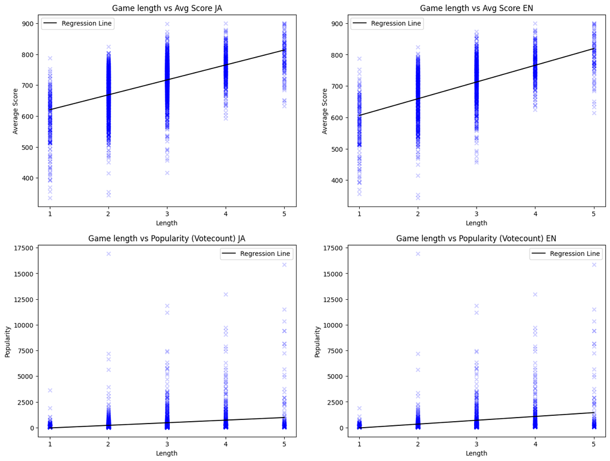

```python
#Let's try mapping game length vs average score, to see if there's much correlation
#VNDB categorizes length into 6 categories
# 1 = Very Short (< 2h)
# 2 = Short (2h - 10h)
# 3 = Medium (10h - 30h)
# 4 = Long (30h - 50h)
# 5 = Very Long (50h+)
fig, ax = plt.subplots(2, 2)

ax[0, 0].scatter(list(vns_unique_ja['length']), list(vns_unique_ja['c_average']), marker='x', alpha=.2, color='blue')
ax[0, 0].set_title('Game length vs Avg Score JA')
ax[0, 0].set_xlabel('Length')
ax[0, 0].set_ylabel('Average Score')

slope, intercept = np.polyfit(list(vns_unique_ja['length']), list(vns_unique_ja['c_average']), 1)
x_fit = np.linspace(min(list(vns_unique_ja['length'])), max(list(vns_unique_ja['length'])), 100)
y_fit = slope * x_fit + intercept
ax[0, 0].plot(x_fit, y_fit, color='black', label='Regression Line')
ax[0, 0].legend()
ax[0, 0].xaxis.set_ticks(np.arange(1,6,1))

#Now let's map game length vs vote count
ax[1, 0].scatter(list(vns_unique_ja['length']), list(vns_unique_ja['c_votecount']), marker='x', alpha=.2, color='blue')
ax[1, 0].set_title('Game length vs Popularity (Votecount) JA')
ax[1, 0].set_xlabel('Length')
ax[1, 0].set_ylabel('Popularity')

slope, intercept = np.polyfit(list(vns_unique_ja['length']), list(vns_unique_ja['c_votecount']), 1)
x_fit = np.linspace(min(list(vns_unique_ja['length'])), max(list(vns_unique_ja['length'])), 100)
y_fit = slope * x_fit + intercept
ax[1, 0].plot(x_fit, y_fit, color='black', label='Regression Line')
ax[1, 0].legend()
ax[1, 0].xaxis.set_ticks(np.arange(1,6,1))


#Do the same for english
ax[0, 1].scatter(list(vns_unique_en['length']), list(vns_unique_en['c_average']), marker='x', alpha=.2, color='blue')
ax[0, 1].set_title('Game length vs Avg Score EN')
ax[0, 1].set_xlabel('Length')
ax[0, 1].set_ylabel('Average Score')

slope, intercept = np.polyfit(list(vns_unique_en['length']), list(vns_unique_en['c_average']), 1)
x_fit = np.linspace(min(list(vns_unique_en['length'])), max(list(vns_unique_en['length'])), 100)
y_fit = slope * x_fit + intercept
ax[0, 1].plot(x_fit, y_fit, color='black', label='Regression Line')
ax[0, 1].legend()
ax[0, 1].xaxis.set_ticks(np.arange(1,6,1))

#Now let's map game length vs vote count
ax[1, 1].scatter(list(vns_unique_en['length']), list(vns_unique_en['c_votecount']), marker='x', alpha=.2, color='blue')
ax[1, 1].set_title('Game length vs Popularity (Votecount) EN')
ax[1, 1].set_xlabel('Length')
ax[1, 1].set_ylabel('Popularity')

slope, intercept = np.polyfit(list(vns_unique_en['length']), list(vns_unique_en['c_votecount']), 1)
x_fit = np.linspace(min(list(vns_unique_en['length'])), max(list(vns_unique_en['length'])), 100)
y_fit = slope * x_fit + intercept
ax[1, 1].plot(x_fit, y_fit, color='black', label='Regression Line')
ax[1, 1].legend()
ax[1, 1].xaxis.set_ticks(np.arange(1,6,1))

fig.set_figwidth(16)
fig.set_figheight(12)
```

As our linear regression models show, there seems to be a generally positive correlation between a visual novel's length and its average score for both Japanese and English releases. This makes sense: users are not as likely to finish a very long game they don't enjoy compared to a shorter game. On the contrary, our regression model for game length vs popularity does not say much, but it's important to note that longer games generally seem to have more "popular" entries that many users have played than shorter games do.

Now let's take a look at visual novels and their popularity over time.

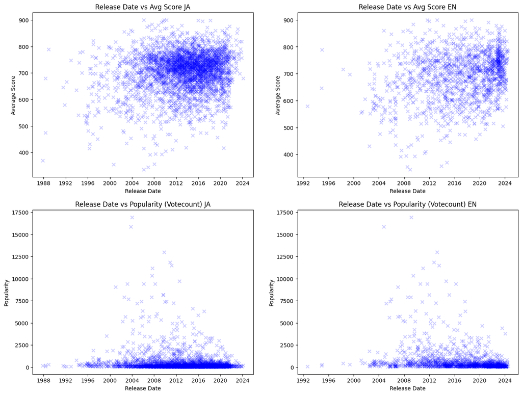

```python
fig, ax = plt.subplots(2, 2)

ax[0, 0].scatter(vns_unique_ja['release_date'], vns_unique_ja['c_average'], marker='x', alpha=.2, color='blue')
ax[0, 0].set_title('Release Date vs Avg Score JA')
ax[0, 0].set_xlabel('Release Date')
ax[0, 0].set_ylabel('Average Score')

#Now let's map game length vs vote count
ax[1, 0].scatter(vns_unique_ja['release_date'], vns_unique_ja['c_votecount'], marker='x', alpha=.2, color='blue')
ax[1, 0].set_title('Release Date vs Popularity (Votecount) JA')
ax[1, 0].set_xlabel('Release Date')
ax[1, 0].set_ylabel('Popularity')


#Do same for english
ax[0, 1].scatter(vns_unique_en['release_date'], vns_unique_en['c_average'], marker='x', alpha=.2, color='blue')
ax[0, 1].set_title('Release Date vs Avg Score EN')
ax[0, 1].set_xlabel('Release Date')
ax[0, 1].set_ylabel('Average Score')

ax[1, 1].scatter(vns_unique_en['release_date'], vns_unique_en['c_votecount'], marker='x', alpha=.2, color='blue')
ax[1, 1].set_title('Release Date vs Popularity (Votecount) EN')
ax[1, 1].set_xlabel('Release Date')
ax[1, 1].set_ylabel('Popularity')

fig.set_figwidth(16)
fig.set_figheight(12)
```

While the data spread for release date vs average score for Japanese releases doesn't reveal much correlation, other than the fact that there are a lot more visual novels with 50+ votes that came out after the year 2004 than before, the English side is a different story. It is clear that there is a high concentration of visual novels that has an english release after 2022 with more than 50 votes, suggesting that either visual novels have increased in popularity since 2022, or that the community is paying more attention to newer releases than older ones, or both. It is important not to misunderstand the data here, however. The release date in the english plots represents its *english* release, not the original release date.

Let's merge the two dataframes so we get a single dataframe with only visual novels that have English releases, but keeping the original Japanese release date.

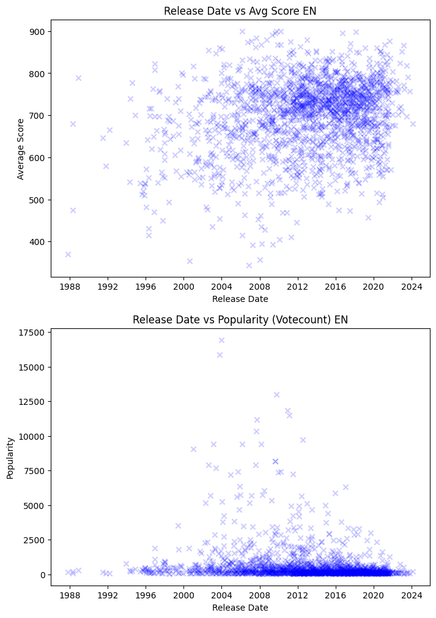

```python
merged_vns = vns_unique_ja.merge(vns_unique_en[['id']], how='left', indicator=True)
vns_unique_en_release_matched = merged_vns[merged_vns['_merge'] == 'both'].drop('_merge', axis=1)

fig, ax = plt.subplots(2, 1)

ax[0].scatter(vns_unique_en_release_matched['release_date'], vns_unique_en_release_matched['c_average'], marker='x', alpha=.2, color='blue')
ax[0].set_title('Release Date vs Avg Score EN')
ax[0].set_xlabel('Release Date')
ax[0].set_ylabel('Average Score')

ax[1].scatter(vns_unique_en_release_matched['release_date'], vns_unique_en_release_matched['c_votecount'], marker='x', alpha=.2, color='blue')
ax[1].set_title('Release Date vs Popularity (Votecount) EN')
ax[1].set_xlabel('Release Date')
ax[1].set_ylabel('Popularity')

fig.set_figwidth(8)
fig.set_figheight(12)
```